# intRo

January 12, 2015

## Introduction

## Do we really need another statistical software package?

Short answer: **yes**

- `R` is great, but requires students to have some knowledge/interest in programming
- `JMP` is powerful, but too big
  - Licenses and inconsistent UI
- New tools recently released to spark an interest in `R`
  - `Swirl` and DataCamp teach `R` programming
  - Project MOSAIC facilitates learning, but assumes knowledge of `R`
- Want students to focus on data analysis rather than fight with software

## What is `intRo`?

- A simple **web-based** application for performing basic data analysis and statistical routines
- Built using `R` and `Shiny`
- Extensible modular structure
- Designed for a first statistics class student
- Assists in the learning of statistics rather than acting as a stand-alone deliverer of statistics education

## Easy

- Focused on aspects of the user interface (UI) and output that make it easy to pick up without training
- Minimal necessary functionality for an introductory statistics course
- Organized around specific tasks a student may perform in the process of a data analysis

[figure not shown]

## Exciting

- Fun, easy to use (available on the web)
- Interactive plots using `ggvis`

**Ulterior motive**: get students excited about programming

- By navigating about the user interface of `intRo`, students are creating a fully-executable `R` script that they can download and run locally
- Viewing their script change real-time within the application

## Extensible

- User interaction with `intRo` is split into bitesize chunks that we call *modules*
- Each module is a self contained set of `R` code that is dynamically added to the application at run time
- `intRo` can be easily extended by the addition of modules within the frame-work underlying the application
- Allows instructors/collaborators to tailor `intRo` to the needs of a particular course

## First look

### http://intro-stats.com

## Classroom

## `intRo` in the wild

- `intRo` will be used this semester in STAT 201
  - Homework assignments and labs will use `intRo` to emphasize class concepts
- `intRo` is a supplement, not the focus of the class

## Homework 1

- *Data*: OECD PISA Results in Focus report to assess the workforce readiness of 15-year old students
- *Goal*: Explore graphically and numerically how the students perceive academics and math
- `intRo` *Tasks*:
  1. Make a barchart of the variable Enjoy.Maths.
  2. Make a summary of the Enjoy.Maths variable. What proportion of these students agree or strongly agree with the statement "I enjoy mathematics"?
  3. Obtain a contingency table and mosaic plot of the relationship between Country and Enjoy.Maths. Print contingency tables with the **Count** and **Column Proportion** values.

## Our turn

## Design decisions

## Consistent UI

Elements of `intRo`: 1) top navigation, 2) side navigation, 3) options panel, 4) results panel, and 5) code panel.

[figure not shown]

## Consistent UI (Cont'd)

- Large, easy to click icons in the page header to help students find exactly what they need easily
- Each module maintains a consistent layout, helping the user to become familiar with the location of the options, the results, and the code
- Documentation website that is consistent with the interface of the application; covers all default modules and makes learning to use `intRo` even more painless

## Modularity

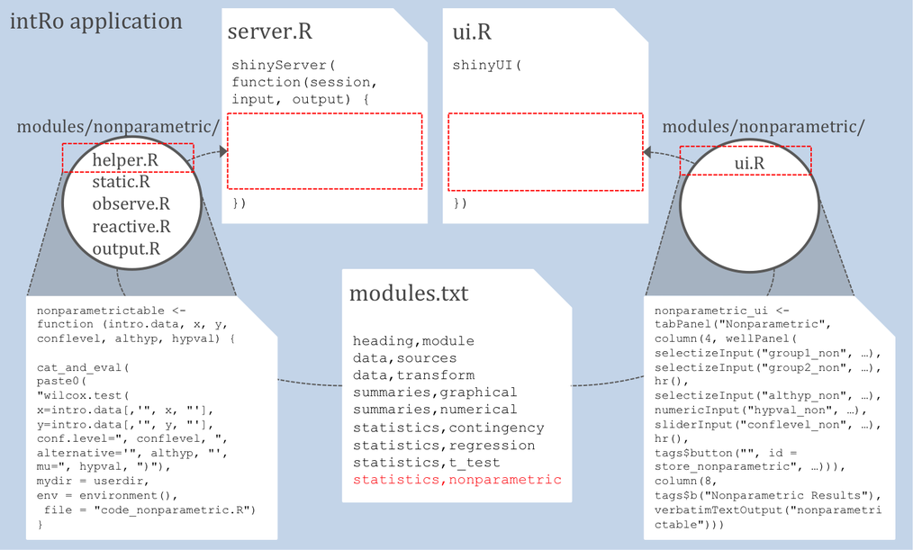

## Modularity (Cont'd)

The interface is created with the following statement

```r
## Source ui
module_info <- read.table("modules/modules.txt", header = TRUE,
                          sep=",")
sapply(file.path("modules", dir("modules")[dir("modules")
                      != "modules.txt"], "ui.R"), source)
## Create the UI
shinyUI(navbarPage("intRo", theme = "bootstrap.min.css",
               tabPanel(title="", icon=icon("home"),
                        fluidRow(
                          do.call(navlistPanel,
                              c(list(id = "side-nav",
                              widths = c(2, 10)), mylist))
                        )
               ), ...
))
```

## Modularity (Cont'd)

The server functions are dynamically generated using a similar method

```r
shinyServer(function(input, output, session) {
  ## Module info
  module_info <- read.table("modules/modules.txt",
                            header = TRUE, sep=",")
  ## Modules
  types <- c("helper.R", "static.R", "observe.R",
             "reactive.R", "output.R")
  modules_tosource <- file.path("modules",
                                apply(expand.grid(
                                module_info$module, types)
                                , 1, paste, collapse = "/"))
  ## Source the modules
  for (mod in modules_tosource) {
    source(mod, local = TRUE)
  }
})
```

## Challenges

## Tradeoffs

We encountered a number of challenges in striving to strike the balance of functionality and ease-of-use:

- Storing the user's results
- Presenting only relevant options to the user
- Producing clean and executable R code

## Storing results

- Users must be able to print results, but only the results they want
- Reactivity makes this somewhat challenging

**Solution**: Store Buttons

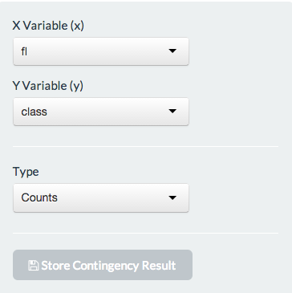

## Storing results (Cont'd)

- Each module contains, at the bottom, a Store button
- When Store is pressed, code is stored in code panel
  - Additional challenge: All options selected must also be stored!
- When user goes to print results, only this particular code is executed

## Presenting choices

- `intRo` is flexible, but must also be simple for the introductory student
- Despite increasing the complexity of the code, we decided to only show options appropriate for the given selections.

**Example**:

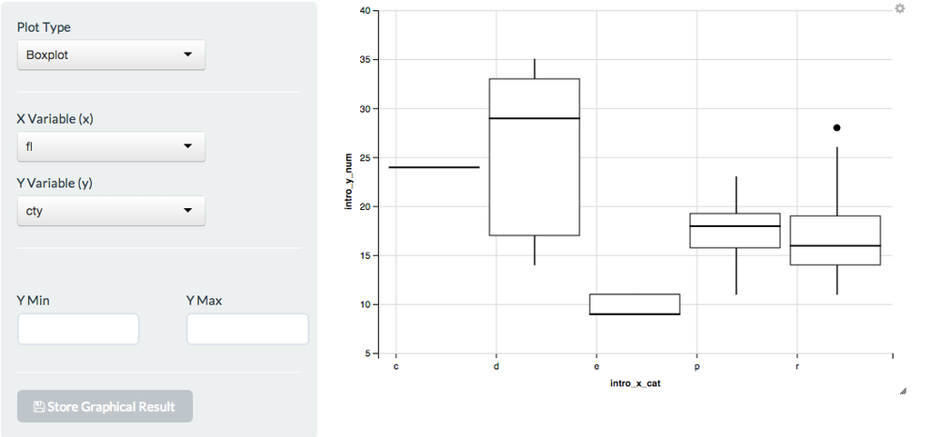

## Presenting choices (Cont'd)

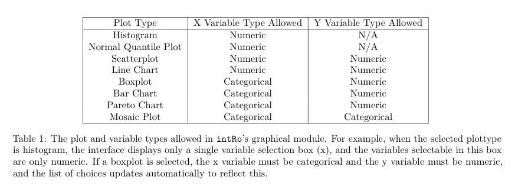

## Producing clean code

Code generated must be:

- Executable on the server
- Executable on the user's machine
- Clean

## Producing clean code (Cont'd)

But how do we handle uploaded data?

```r
file.choose <- function () {
    return(input$data_own[,"datapath"])
}
```

Now we can provide to the user *and* the server:

```r
intro.data <- read.csv(file.choose())
```

## Future work

## What's next?

- Module creation package
- Server load
- Use in other classes

## Module creation package

*Modularity* is a key feature of `intRo`, but module creation is currently:

- Undocumented
- Entirely manual
- Unnecessarily lengthy

**Idea**: R package (with associated Shiny app?) to automate creation of `intRo` modules

## Server load

Limited testing has been done to assess how `intRo` handles heavy user load

- Dozens of students at accessing app at once
- Simultaneous larger computations like printing results

More server resources may need to be devoted to handle this, particularly if `intRo` is more widely adopted

## More classes

- We would like work with instructors to get `intRo` into more classes
- Module creation package will allow it to suit more curricula
- We welcome collaborators interested in extending `intRo` to submit pull requests on GitHub (http://www.github.com/gammarama/intRo)
  - Additional modules
  - Improvements and bug fixes

## Special thanks

Dr. Cook, for guiding many of the features and interface decisions, and helping test the functionality in preparation for STAT 201

## Any questions?

### Thank you!

Contact:  
ajkaplan@iastate.edu  
erichare@iastate.edu